# Regresi dengan Peubah Lag

# Library

```r
library(dLagM)
library(dynlm)
library(MLmetrics)
library(lmtest)
library(car)
```

```r
library(ggplot2)
```

# Data

```r
data <- read.csv("D:\\Mine\\Kuliah Journey\\Semester 5\\MPDW\\mpdw_066\\Pertemuan 3\\NewDelhi_Air_quality.csv")
head(data)
```

```
##   X  AQI       CO      datetime        no2       o3      pm10     pm25
## 1 0 30.2 198.6027 2022-10-21:18 0.04685717 55.78995 10.486722 5.637410
## 2 1 28.2 197.6013 2022-10-21:19 0.04645554 54.93164 10.719325 4.618169
## 3 2 26.6 198.6027 2022-10-21:20 0.04685717 54.64554 11.155578 3.520902
## 4 3 25.0 201.9405 2022-10-21:21 0.04819594 55.07469 11.116206 2.225919
## 5 4 26.0 205.2784 2022-10-21:22 0.04886533 55.78995 10.405250 1.979471
## 6 5 26.0 208.6163 2022-10-21:23 0.05020411 56.50520  9.402518 1.792677
##         so2     timestamp_local       timestamp_utc         ts
## 1 0.3874302 2022-10-21T23:00:00 2022-10-21T18:00:00 1666375200
## 2 0.4097819 2022-10-22T00:00:00 2022-10-21T19:00:00 1666378800
## 3 0.4023313 2022-10-22T01:00:00 2022-10-21T20:00:00 1666382400
## 4 0.3762543 2022-10-22T02:00:00 2022-10-21T21:00:00 1666386000
## 5 0.3390014 2022-10-22T03:00:00 2022-10-21T22:00:00 1666389600
## 6 0.3129244 2022-10-22T04:00:00 2022-10-21T23:00:00 1666393200
```

# Eksplorasi Data

```r
str(data)
```

```
## 'data.frame':    72 obs. of  12 variables:
##  $ X              : int  0 1 2 3 4 5 6 7 8 9 ...
##  $ AQI            : num  30.2 28.2 26.6 25 26 26 26 24 23 24 ...
##  $ CO             : num  199 198 199 202 205 ...
##  $ datetime       : chr  "2022-10-21:18" "2022-10-21:19" "2022-10-21:20" "2022-10-21:21" ...
##  $ no2            : num  0.0469 0.0465 0.0469 0.0482 0.0489 ...
##  $ o3             : num  55.8 54.9 54.6 55.1 55.8 ...
##  $ pm10           : num  10.5 10.7 11.2 11.1 10.4 ...
##  $ pm25           : num  5.64 4.62 3.52 2.23 1.98 ...
##  $ so2            : num  0.387 0.41 0.402 0.376 0.339 ...
##  $ timestamp_local: chr  "2022-10-21T23:00:00" "2022-10-22T00:00:00" "2022-10-22T01:00:00" "2022-10-22T02:00:00" ...
##  $ timestamp_utc  : chr  "2022-10-21T18:00:00" "2022-10-21T19:00:00" "2022-10-21T20:00:00" "2022-10-21T21:00:00" ...
##  $ ts             : int  1666375200 1666378800 1666382400 1666386000 1666389600 1666393200 1666396800 1666400400 1666404000 1666407600 ...
```

```r
dim(data)
```

```
## [1] 72 12
```

Data memiliki 72 baris dan 12 kolom.

```r
colSums(is.na(data))
```

```
##               X             AQI              CO        datetime             no2
##               0               0               0               0               0
##              o3            pm10            pm25             so2 timestamp_local
##               0               0               0               0               0
##   timestamp_utc              ts
##               0               0
```

Tidak terdapat missing value pada data.

# Split

```r
n <- nrow(data)

n_train <- floor(0.8 * n)

# bagi data
train <- data[1:n_train, ]
test  <- data[(n_train+1):n, ]

# ubah ke time series
train.ts <- ts(train)
test.ts  <- ts(test)
data.ts <- ts(data)
```

Data dibagi menjadi dua bagian, yaitu 80% data training dan 20% data testing. Data training digunakan untuk membangun model, sedangkan data testing digunakan untuk menguji kemampuan model dalam melakukan peramalan pada data yang belum digunakan saat pemodelan. Training sebanyak 57 dan Testing sebanyak 15.

# Model Koyck

Model Koyck digunakan untuk melihat pengaruh PM2.5 saat ini dan AQI periode sebelumnya terhadap AQI saat ini. Secara umum:
$$Y_t = \alpha + \beta X_t + \lambda Y_{t-1} + \epsilon_t$$
Dengan:
- $Y_t$ = AQI saat ini
- $X_t$ = PM2.5 saat ini
- $Y_{t-1}$ = AQI periode sebelumnya

## Pemodelan

```r
model.koyck <- koyckDlm(x = train$pm25, y = train$AQI)
summary(model.koyck)
```

```
##
## Call:
## "Y ~ (Intercept) + Y.1 + X.t"
##
## Residuals:
##      Min       1Q   Median       3Q      Max
## -2.19768 -0.57669 -0.03615  0.58158  2.18318
##
## Coefficients:
##             Estimate Std. Error t value Pr(>|t|)
## (Intercept)  4.54910    1.77579   2.562   0.0133 *
## Y.1          0.87326    0.05731  15.237   <2e-16 ***
## X.t         -0.56825    0.27658  -2.055   0.0449 *
## ---
## Signif. codes:  0 '***' 0.001 '**' 0.01 '*' 0.05 '.' 0.1 ' ' 1
##
## Residual standard error: 0.8986 on 53 degrees of freedom
## Multiple R-Squared: 0.8303,  Adjusted R-squared: 0.8239
## Wald test: 129.9 on 2 and 53 DF,  p-value: < 2.2e-16
##
## Diagnostic tests:
## NULL
##
##                             alpha       beta      phi
## Geometric coefficients:  35.89204 -0.5682546 0.873256
```

```r
AIC(model.koyck)
```

```
## [1] 151.8615
```

```r
BIC(model.koyck)
```

```
## [1] 159.9629
```

Dari hasil tersebut, didapat bahwa peubah $x_t$ dan $y_{t-1}$ signifikan pada taraf 5% dengan $p-value < 0.05$. Hal ini menunjukkan bahwa PM2.5 pada periode saat ini dan AQI pada satu periode sebelumnya berpengaruh signifikan terhadap AQI pada periode saat ini. Model keseluruhannya sebagai berikut:

$$\hat{Y}_t = 4.54910 - 0.56825X_t + 0.87326Y_{t-1}$$

## Peramalan dan Akurasi

```r
fore.koyck <- dLagM::forecast(model = model.koyck, x = test$pm25, h = 15)
fore.koyck
```

```
## $forecasts
##  [1] 24.95927 24.78189 24.49412 24.19650 23.90670 23.66965 23.52745 23.47683
##  [9] 23.47525 23.49718 23.52224 23.54830 23.55405 23.53805 23.54349
##
## $call
## forecast.koyckDlm(model = model.koyck, x = test$pm25, h = 15)
##
## attr(,"class")
## [1] "forecast.koyckDlm" "dLagM"
```

```r
# Akurasi Data Test
mape.koyck <- MLmetrics::MAPE(fore.koyck$forecasts, test$AQI)
mape.koyck
```

```
## [1] 0.1394956
```

```r
GoF(model.koyck)
```

```
##              n       MAE         MPE       MAPE      sMAPE     MASE       MSE
## model.koyck 56 0.6708393 -0.00101664 0.02495405 0.02490925 1.048186 0.7642032
##                  MRAE   GMRAE
## model.koyck 836328982 13944.2
```

Model Koyck memiliki rata-rata kesalahan absolut relatif sekitar 13.95% pada data testing. Artinya, secara rata-rata hasil peramalan AQI dari model Koyck memiliki penyimpangan sekitar 13.95% dari nilai aktualnya. Model sudah cukup baik.

# Regression with Distributed Lag

Model ini digunakan untuk melihat bagaimana pengaruh suatu variabel independen ($X$) terhadap variabel dependen ($Y$) tidak hanya terjadi pada periode saat ini ($t$), tetapi juga merembet atau tertunda pada periode-periode sebelumnya (menggunakan lag hingga orde $q$). Model secara umum:
$$Y_t = \alpha + \beta_0 X_t + \beta_1 X_{t-1} + \beta_2 X_{t-2} + \cdots
+ \beta_q X_{t-q} + \varepsilon_t$$
Dengan:
- $Y_t$ = variabel dependen pada periode $t$
- $X_t$ = variabel independen pada periode sekarang
- $X_{t-1}$ = $X$ satu periode sebelumnya
- $X_{t-2}$ = $X$ dua periode sebelumnya
- $X_{t-q}$ = $X$ sampai lag ke-$q$
- $\beta_0$ = pengaruh langsung $X$ terhadap $Y$
- $\beta_1, \ldots, \beta_q$ = pengaruh tertunda (lagged effect) $X$ terhadap $Y$
- $\varepsilon_t$ = error

## Lag Optimum

Pemilihan lag dilakukan berdasarkan kriteria AIC, sehingga model dengan nilai AIC yang lebih kecil lebih dipertimbangkan sebagai model yang lebih baik.

```r
#penentuan lag optimum
auto.dlm <- finiteDLMauto(formula = AQI ~ pm25,
              data = data.frame(train), q.min = 1, q.max = 15,
              model.type = "dlm", error.type = "AIC", trace = TRUE)
auto.dlm
```

```
##    q - k    MASE      AIC      BIC     GMRAE    MBRAE R.Adj.Sq    Ljung-Box
## 15    15 1.18813 131.9477 163.2258  66648.21  0.64242  0.78761 8.102963e-05
## 14    14 1.23999 133.6157 163.5561  92307.75  0.64620  0.78941 4.359756e-04
## 13    13 1.40219 147.7745 176.3215 117167.40  1.49047  0.72166 5.424161e-04
## 12    12 1.57870 163.8501 190.9500  90679.85 -2.46159  0.61662 2.303503e-06
## 11    11 1.75216 172.8723 198.4733  89648.55 -0.40235  0.55714 1.141694e-07
## 10    10 1.79180 181.4052 205.4571  69409.72  1.83368  0.50588 4.814509e-08
## 9      9 1.95552 192.2161 214.6706  59217.09 -0.65007  0.43896 3.162063e-08
## 8      8 2.01622 196.5406 217.3506  51171.73  0.67925  0.46088 2.929916e-10
## 7      7 1.96730 197.4880 216.6082  40347.66  0.63118  0.49602 6.697151e-10
## 6      6 1.83971 198.5178 215.9042  28047.21  0.57217  0.50809 5.471995e-10
## 5      5 1.86028 201.4950 217.1050  31164.02 -0.91742  0.50052 9.449556e-10
## 4      4 1.97485 207.2937 221.0857  40854.21  0.73804  0.46486 3.806880e-09
## 3      3 2.24020 217.2830 229.2169  49384.27  0.80165  0.38957 1.527662e-09
## 2      2 2.28777 229.4667 239.5034  38705.59  1.30509  0.26580 9.176708e-07
## 1      1 2.37966 242.0647 250.1661  31042.32  0.66469  0.11843 2.695019e-09
```

Berdasarkan output tersebut, lag optimum didapatkan ketika lag=15. Selanjutnya dilakukan pemodelan untuk lag=15.

## Pemodelan

```r
#model dlm dengan lag optimum
model.dlm2 <- dlm(x = train$pm25,y = train$AQI , q = 15)
summary(model.dlm2)
```

```
##
## Call:
## lm(formula = model.formula, data = design)
##
## Residuals:
##     Min      1Q  Median      3Q     Max
## -1.6765 -0.5299 -0.2349  0.5324  1.7533
##
## Coefficients:
##             Estimate Std. Error t value Pr(>|t|)
## (Intercept)  51.5690     2.2109  23.325  < 2e-16 ***
## x.t         -19.2819     4.9899  -3.864 0.000702 ***
## x.1           5.7764    11.7631   0.491 0.627668
## x.2           1.1007    15.1592   0.073 0.942693
## x.3           7.1495    15.9173   0.449 0.657181
## x.4         -11.8734    16.3060  -0.728 0.473278
## x.5          12.5614    16.4719   0.763 0.452842
## x.6           5.9188    15.1391   0.391 0.699139
## x.7          -5.0855    15.5296  -0.327 0.746038
## x.8          -4.1859    14.8707  -0.281 0.780656
## x.9           2.6671    13.4296   0.199 0.844181
## x.10         -4.0832    11.7634  -0.347 0.731415
## x.11          0.3419     9.1492   0.037 0.970489
## x.12         -1.7538     5.7131  -0.307 0.761398
## x.13          2.6483     4.4131   0.600 0.553839
## x.14         -1.7924     4.2067  -0.426 0.673689
## x.15         -2.0430     1.9050  -1.072 0.293759
## ---
## Signif. codes:  0 '***' 0.001 '**' 0.01 '*' 0.05 '.' 0.1 ' ' 1
##
## Residual standard error: 0.9828 on 25 degrees of freedom
## Multiple R-squared:  0.8705, Adjusted R-squared:  0.7876
## F-statistic:  10.5 on 16 and 25 DF,  p-value: 2.058e-07
##
## AIC and BIC values for the model:
##        AIC      BIC
## 1 131.9477 163.2257
```

Dari hasil tersebut terdapat peubah yang berpengaruh signifikan terhadap taraf nyata 5% yaitu $x_t$. Hal ini menunjukkan bahwa nilai $x$ pada periode saat ini berpengaruh signifikan terhadap nilai $y$ pada periode saat ini. Adapun keseluruhan model yang terbentuk adalah

$$\hat{Y}_t = 51.5690-19.2819X_t + 5.7764X_{t-1} + 1.1007X_{t-2} + ... -
2.0430X_{t-15}$$

## Peramalan dan Akurasi

```r
fore.dlm2 <- dLagM::forecast(model = model.dlm2, x = test$pm25, h = 15)
fore.dlm2
```

```
## $forecasts
##  [1] 17.10954 13.82320 12.60434 14.06386 14.15354 18.31292 22.27792 26.08446
##  [9] 25.95982 25.18710 23.92205 22.29512 19.01305 17.74475 18.13894
##
## $call
## forecast.dlm(model = model.dlm2, x = test$pm25, h = 15)
##
## attr(,"class")
## [1] "forecast.dlm" "dLagM"
```

```r
# akurasi data test
mape.dlm2<- MAPE(fore.dlm2$forecasts, test$AQI)
mape.dlm2
```

```
## [1] 0.2352866
```

```r
# akurasi data training
GoF(model.dlm2)
```

```
##             n      MAE           MPE       MAPE      sMAPE    MASE       MSE
## model.dlm2 42 0.637533 -0.0007539658 0.02332862 0.02337344 1.18813 0.5749868
##                  MRAE    GMRAE
## model.dlm2 3103162827 66648.21
```

Model DLM memiliki rata-rata kesalahan absolut relatif sekitar 23.52% pada data testing. Artinya, secara rata-rata hasil peramalan AQI dari model DLM memiliki penyimpangan sekitar 23.52% dari nilai aktualnya. Model tidak sebaik Koyck.

# Model Autoregressive

ARDL (Autoregressive Distributed Lag) menggabungkan lag dari variabel dependen (autoregressive) dan lag dari variabel independen (distributed lag) dalam satu persamaan untuk menganalisis hubungan jangka pendek dan jangka panjang antarvariabel. Secara umum:
$$Y_t = \alpha + \phi_1 Y_{t-1} + \cdots + \phi_p Y_{t-p} + \beta_0 X_t +
\cdots + \beta_q X_{t-q} + \varepsilon_t$$
Dengan:
$Y_t$= variabel dependen pada periode
$X_t$ = variabel independen pada periode
$Y_{t-i}$ = nilai $Y$ pada periode sebelumnya hingga lag ke-$p$
$X_{t-j}$ = nilai $X$ pada periode sebelumnya hingga lag ke-$q$
$\alpha$ = konstanta/intersep
$\phi_i$ = koefisien lag dari variabel dependen $Y$
$\beta_j$ = koefisien variabel independen $X$ dan lag-nya
$p$ = maksimum lag untuk variabel dependen $Y$
$q$ = maksimum lag untuk variabel independen $X$
$\varepsilon_t$ = error pada periode t

## Lag Optimum

```r
#penentuan lag optimum
model.ardl.opt <- ardlBoundOrders(data = data.frame(train), ic = "AIC",
                                  formula = AQI ~ pm25 )
model.ardl.opt
```

```
## $p
##   pm25
## 1   15
##
## $q
## [1] 15
##
## $Stat.table
##            q = 1     q = 2     q = 3     q = 4     q = 5     q = 6     q = 7
## p = 1  140.96343 138.54505 132.99479 123.55712 123.90746 121.40329 114.20470
## p = 2  138.30775 138.82888 133.62202 125.54055 122.61537 113.66417 110.25671
## p = 3  134.13415 134.13415 135.57031 127.54040 123.92956 109.44506 108.85286
## p = 4  118.62364 120.57981 120.57981 122.23541 118.24755 108.18873 107.94733
## p = 5  114.71656 116.67961 117.27554 117.27554 118.92580 107.57522 107.98734
## p = 6  105.13284 107.11324 106.83109 108.05850 108.05850 108.76605 109.57530
## p = 7  113.19250 114.39875 111.17772 109.69456 107.88697 107.88697 109.84485
## p = 8   99.79025 101.61094 101.74121 100.88003  99.95660 100.94338 100.94338
## p = 9   88.49074  87.80524  87.86929  87.07306  84.78252  85.59977  87.48566
## p = 10  86.43195  87.60610  79.65714  80.53203  75.84789  77.48558  79.48413
## p = 11  99.27857  99.31693  92.92575  89.35067  80.26855  81.79503  83.18196
## p = 12 108.14062 103.51519  96.04352  93.91544  85.18422  86.33714  87.72503
## p = 13 109.41507 103.52229  97.67071  96.32837  84.85661  86.34649  87.75378
## p = 14 110.00106  99.71683  90.89914  88.67776  80.05991  81.35374  82.29160
## p = 15 105.27088 102.33304  93.63709  90.76521  76.56629  78.21673  79.71004
##            q = 8     q = 9    q = 10    q = 11    q = 12    q = 13    q = 14
## p = 1  114.80886 115.64636 112.72216 110.41750 107.81635 101.64925 102.38914
## p = 2  110.14509 109.79120 110.10406 106.63492  96.60230  96.08167  94.63556
## p = 3  109.20134 109.47553 108.92528 105.24575  92.56052  94.12554  94.29542
## p = 4  108.22520 108.75388 108.92572 107.16073  93.37342  95.07484  95.97208
## p = 5  103.26125 101.39410 101.10826  95.87093  87.21504  87.01273  88.31178
## p = 6  103.66223 101.94872  99.21396  94.78001  78.08871  73.27211  71.86812
## p = 7  105.11176 102.48079  96.50323  92.27520  79.50622  73.57054  70.44913
## p = 8  102.41321  98.42151  95.19426  92.91922  80.21984  71.48090  70.36811
## p = 9   87.48566  88.36519  79.51468  78.93501  78.20636  73.45340  72.11225
## p = 10  79.62153  79.62153  81.49450  80.77921  80.13557  75.00996  73.76570
## p = 11  81.80315  81.98892  81.98892  82.01082  81.60699  76.34906  69.90165
## p = 12  84.43373  82.29121  83.09421  83.09421  80.77141  75.20715  69.42366
## p = 13  83.75021  82.90930  84.84889  83.00204  83.00204  76.18047  65.30612
## p = 14  79.15810  74.31320  76.30929  71.90703  73.73493  73.73493  67.11178
## p = 15  71.16979  61.35428  58.67383  54.61943  55.55869  54.32641  54.32641
##          q = 15
## p = 1  98.88454
## p = 2  92.20168
## p = 3  88.90993
## p = 4  90.88714
## p = 5  88.20222
## p = 6  74.14324
## p = 7  71.14269
## p = 8  71.98584
## p = 9  73.94256
## p = 10 74.62778
## p = 11 72.56672
## p = 12 62.57944
## p = 13 56.90483
## p = 14 55.15744
## p = 15 55.83027
##
## $min.Stat
## [1] 54.32641
```

```r
min_p = c()

for(i in 1:15){
  min_p[i] = min(model.ardl.opt$Stat.table[[i]])
}

q_opt = which(min_p == min(min_p, na.rm = TRUE))
p_opt = sapply(q_opt, function(q){
  which(model.ardl.opt$Stat.table[[q]] ==
          min(model.ardl.opt$Stat.table[[q]], na.rm = TRUE))
})
data.frame(
  q_optimum = q_opt,
  p_optimum = p_opt,
  AIC = model.ardl.opt$min.Stat
)
```

```
##   q_optimum p_optimum      AIC
## 1        13        15 54.32641
## 2        14        15 54.32641
```

Didapat q optimum sebesar 13/14 dan p optimum sebesar 15 dengan AIC = 54.32641

## Pemodelan

```r
model.ardl1 <- ardlDlm(
  formula = AQI ~ pm25,
  data = train,
  p = 15,
  q = 13
)
summary(model.ardl1)
```

```
##
## Time series regression with "ts" data:
## Start = 16, End = 57
##
## Call:
## dynlm(formula = as.formula(model.text), data = data)
##
## Residuals:
##      Min       1Q   Median       3Q      Max
## -0.64838 -0.13502  0.00481  0.17134  0.86764
##
## Coefficients:
##             Estimate Std. Error t value Pr(>|t|)
## (Intercept) 24.87968   22.66122   1.098    0.294
## pm25.t      -7.11241    4.25697  -1.671    0.121
## pm25.1       3.47789    8.53544   0.407    0.691
## pm25.2       8.90362    9.66141   0.922    0.375
## pm25.3      -1.07959   10.05701  -0.107    0.916
## pm25.4      -6.86960    9.90485  -0.694    0.501
## pm25.5       6.87988   10.75069   0.640    0.534
## pm25.6      -0.37136    9.80263  -0.038    0.970
## pm25.7      -6.23839   10.18498  -0.613    0.552
## pm25.8      -5.20919   10.03437  -0.519    0.613
## pm25.9       6.03514    8.92242   0.676    0.512
## pm25.10     -0.98745    8.01662  -0.123    0.904
## pm25.11     -3.96468    6.60644  -0.600    0.560
## pm25.12      5.00228    4.51517   1.108    0.290
## pm25.13     -0.81745    2.82640  -0.289    0.777
## pm25.14     -2.72188    2.80293  -0.971    0.351
## pm25.15      1.92192    1.48600   1.293    0.220
## AQI.1        0.27216    0.26797   1.016    0.330
## AQI.2        0.36118    0.30578   1.181    0.260
## AQI.3        0.26293    0.29912   0.879    0.397
## AQI.4       -0.07305    0.29697  -0.246    0.810
## AQI.5        0.16026    0.27687   0.579    0.573
## AQI.6       -0.28049    0.27217  -1.031    0.323
## AQI.7       -0.10846    0.27293  -0.397    0.698
## AQI.8        0.11137    0.26048   0.428    0.677
## AQI.9       -0.18961    0.26130  -0.726    0.482
## AQI.10      -0.30069    0.26231  -1.146    0.274
## AQI.11      -0.08653    0.29598  -0.292    0.775
## AQI.12       0.34988    0.29726   1.177    0.262
## AQI.13      -0.15758    0.26881  -0.586    0.569
##
## Residual standard error: 0.5589 on 12 degrees of freedom
## Multiple R-squared:  0.9799, Adjusted R-squared:  0.9313
## F-statistic: 20.17 on 29 and 12 DF,  p-value: 1.696e-06
```

Model terlalu kompleks, tidak ada peubah yang signifikan. Mencari alternatif

```r
model.ardl <- ardlDlm(
  formula = AQI ~ pm25,
  data = train,
  p = 10,
  q = 5
)
summary(model.ardl)
```

```
##
## Time series regression with "ts" data:
## Start = 11, End = 57
##
## Call:
## dynlm(formula = as.formula(model.text), data = data)
##
## Residuals:
##      Min       1Q   Median       3Q      Max
## -0.81654 -0.26572 -0.05465  0.31496  1.13760
##
## Coefficients:
##             Estimate Std. Error t value Pr(>|t|)
## (Intercept) 13.00310    3.00724   4.324 0.000156 ***
## pm25.t      -8.16270    2.81553  -2.899 0.006934 **
## pm25.1       8.44147    5.50194   1.534 0.135443
## pm25.2       1.15137    6.55648   0.176 0.861781
## pm25.3       1.61045    6.34644   0.254 0.801415
## pm25.4      -6.54487    6.12607  -1.068 0.293878
## pm25.5       3.43751    6.11516   0.562 0.578204
## pm25.6       1.85719    5.26252   0.353 0.726624
## pm25.7      -6.76534    3.15417  -2.145 0.040179 *
## pm25.8       2.39986    1.86594   1.286 0.208232
## pm25.9       2.53522    1.84632   1.373 0.179892
## pm25.10     -2.16776    0.89161  -2.431 0.021231 *
## AQI.1        0.65361    0.16976   3.850 0.000575 ***
## AQI.2        0.34356    0.21146   1.625 0.114696
## AQI.3        0.08807    0.20594   0.428 0.671958
## AQI.4       -0.08596    0.20837  -0.413 0.682892
## AQI.5       -0.31219    0.15410  -2.026 0.051753 .
## ---
## Signif. codes:  0 '***' 0.001 '**' 0.01 '*' 0.05 '.' 0.1 ' ' 1
##
## Residual standard error: 0.5655 on 30 degrees of freedom
## Multiple R-squared:  0.952,  Adjusted R-squared:  0.9264
## F-statistic: 37.16 on 16 and 30 DF,  p-value: 2.064e-15
```

```r
AIC(model.ardl)
```

```
## [1] 94.69716
```

```r
BIC(model.ardl)
```

```
## [1] 127.9998
```

Berdasarkan uji parsial pada taraf 5%, peubah yang berpengaruh signifikan terhadap AQI adalah $x_t$, $x_{t-7}$, $x_{t-10}$, dan $y_{t-1}$, serta $y_{t-5}$ pada taraf 10%. Hal ini menunjukkan bahwa PM2.5 saat ini, PM2.5 tujuh dan sepuluh periode sebelumnya, serta AQI satu periode sebelumnya berpengaruh signifikan terhadap AQI saat ini. Selain itu, AQI lima periode sebelumnya $y_{t-5}$ juga berpengaruh signifikan pada taraf 10%.. Model keseluruhan dapat dilihat sebagai berikut:

$$\hat{Y}_t = 13.00310 - 8.16270X_t + ... - 0.31219Y_{t-5}$$

## Peramalan dan Akurasi

```r
fore.ardl <- dLagM:::forecast.ardlDlm(model.ardl, x=test$pm25, h=15)
fore.ardl
```

```
## $forecasts
##  [1] 22.41778 21.22156 20.68161 21.00496 20.86753 22.52107 23.97627 25.02437
##  [9] 25.19905 25.01570 24.65240 23.92171 22.42729 21.48525 21.19786
##
## $call
## dLagM:::forecast.ardlDlm(model = model.ardl, x = test$pm25, h = 15)
##
## attr(,"class")
## [1] "forecast.ardlDlm" "dLagM"
```

```r
# akurasi data tes
mape.ardl <- MAPE(fore.ardl$forecasts, test$AQI)
mape.ardl
```

```
## [1] 0.1266511
```

```r
#akurasi data training
GoF(model.ardl)
```

```
##             n       MAE           MPE      MAPE      sMAPE     MASE       MSE
## model.ardl 47 0.3617827 -0.0002772485 0.0131938 0.01319829 0.640077 0.2041294
##                  MRAE    GMRAE
## model.ardl 1744313542 23776.21
```

Model ARDL memiliki rata-rata kesalahan absolut relatif sekitar 12.67% pada data testing. Artinya, secara rata-rata hasil peramalan AQI dari model ARDL memiliki penyimpangan sekitar 12.67% dari nilai aktualnya. Model lebih baik daripada Koyck dan DLM.

# Perbandingan

```r
akurasi <- matrix(c(mape.koyck, mape.dlm2, mape.ardl))
row.names(akurasi)<- c("Koyck","DLM 2","Autoregressive")
colnames(akurasi) <- c("MAPE")
akurasi
```

```
##                     MAPE
## Koyck          0.1394956
## DLM 2          0.2352866
## Autoregressive 0.1266511
```

Berdasarkan hasil evaluasi menggunakan MAPE pada data testing, model Koyck menghasilkan nilai MAPE sebesar 13.95%, model DLM sebesar 23.53%, dan model ARDL sebesar 12.67%. Dengan demikian, model ARDL memiliki kemampuan peramalan terbaik karena menghasilkan nilai kesalahan paling kecil. Sementara itu, model DLM menghasilkan nilai MAPE terbesar sehingga memiliki kemampuan peramalan paling rendah dibandingkan kedua model lainnya.

# Plot

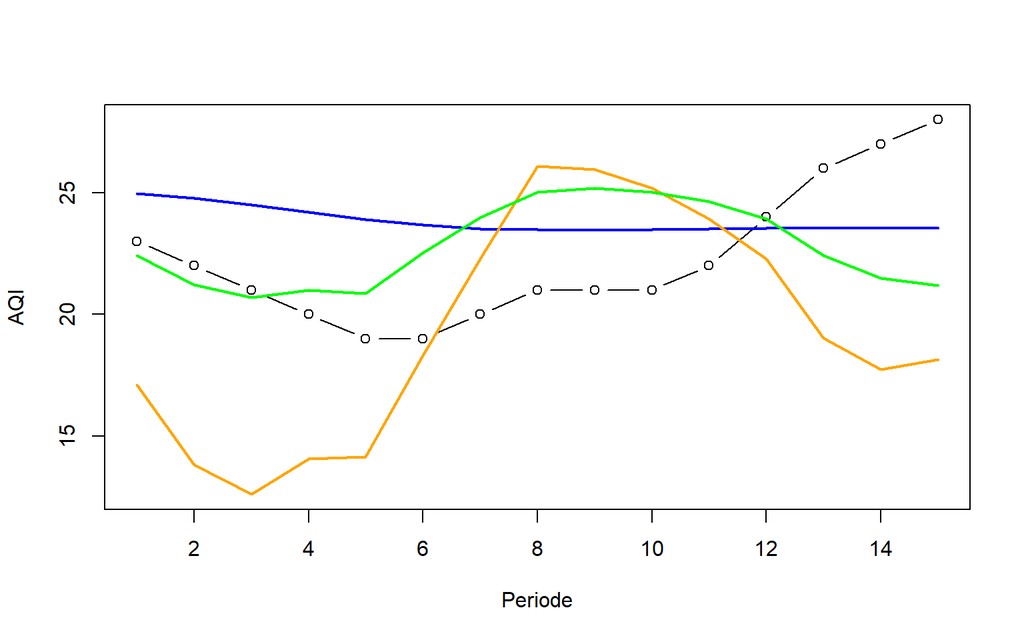

```r
ylim_all <- range(c(
  test$AQI,
  fore.koyck$forecasts,
  fore.dlm2$forecasts,
  fore.ardl$forecasts
), na.rm = TRUE)

plot(test$AQI,
     type = "b",
     col = "black",
     ylim = ylim_all,
     xlab = "Periode",
     ylab = "AQI")

lines(fore.koyck$forecasts, col = "blue", lwd = 2)
lines(fore.dlm2$forecasts, col = "orange", lwd = 2)
lines(fore.ardl$forecasts, col = "green", lwd = 2)
```

Secara visual, hasil peramalan model ARDL cenderung lebih mendekati pola AQI aktual dibandingkan model DLM dan Koyck. Hal tersebut konsisten dengan nilai MAPE, dimana model ARDL menghasilkan kesalahan peramalan paling kecil.